# DMHR_WJTH2

### Assignment A [25 marks]

The NHS has been challenged to make “efficiency savings” and you have been commissioned by an NHS executive to review, document and assess GP prescribing costs. Using data from the HSCIC GP Practice Prescribing dataset for your assigned city only, address the following queries using a combination of narrative, tables, figures and descriptive statistcs:

Identify all GP practices and produce a table with the total number of prescriptions and their total actual cost (using the ACT COST column).

Find the top ten most/least frequently prescribed medications across all practices. What is their total actual cost and how does that compare to the overall actual costs of each practice and of the entire city?

Find the top ten most expensive medications and calculate their total actual cost.

How does prescribing (frequency and costs) in your city compare when using prescribing data from Cambridge as a reference?

Pandas dataframes can also be queried using SLQL! The code snippet below gives you an example of how to execute an SQL statement using pandasql. Using SQL, produce a table that provides the number of GP practices per city, ordered in descending order.

```python
#preliminaries
import pandas as pd
import numpy as np

%matplotlib inline
import random
import matplotlib.pyplot as plt
```

```python
#Load data from URLs
# Import package
from urllib.request import urlretrieve

# Assign url of file: url
url1 = 'https://s3.eu-west-2.amazonaws.com/dmhr-data/practices_Dec2015.csv'

# Read file into a DataFrame and print its head
cols1 = ['period', 'practice', 'practicename', 'centrename', 'street', 'city', 'county', 'postcode']
practicedataset = pd.read_csv(url1, header=None, names=cols1, index_col=False)
practicedataset.head()
```

|  | period | practice | practicename | centrename | street | city | county | postcode |
| --- | --- | --- | --- | --- | --- | --- | --- | --- |
| 0 | 201512 | A81001 | THE DENSHAM SURGERY | THE HEALTH CENTRE | LAWSON STREET | STOCKTON ON TEES | CLEVELAND | TS18 1HU |
| 1 | 201512 | A81002 | QUEENS PARK MEDICAL CENTRE | QUEENS PARK MEDICAL CTR | FARRER STREET | STOCKTON ON TEES | CLEVELAND | TS18 2AW |
| 2 | 201512 | A81003 | VICTORIA MEDICAL PRACTICE | THE HEALTH CENTRE | VICTORIA ROAD | HARTLEPOOL | CLEVELAND | TS26 8DB |
| 3 | 201512 | A81004 | WOODLANDS ROAD SURGERY | 6 WOODLANDS ROAD |  | MIDDLESBROUGH | CLEVELAND | TS1 3BE |
| 4 | 201512 | A81005 | SPRINGWOOD SURGERY | SPRINGWOOD SURGERY | RECTORY LANE | GUISBOROUGH |  | TS14 7DJ |

```python
url2 = 'https://s3.eu-west-2.amazonaws.com/dmhr-data/prescribing_Dec2015.csv'
cols2 = ['sha', 'pct', 'practice', 'bnf_code', 'bnf_name', 'items', 'nic', 'act_cost', 'quantity', 'period']
prescribingdataset = pd.read_csv(url2, header=None, names=cols2, index_col=False, skiprows=1)
prescribingdataset.head()
```

|  | sha | pct | practice | bnf_code | bnf_name | items | nic | act_cost | quantity | period |
| --- | --- | --- | --- | --- | --- | --- | --- | --- | --- | --- |
| 0 | Q44 | RJN | Y05218 | 0501013K0AAAJAJ | Co-Amoxiclav_Tab 500mg/125mg | 1 | 3.59 | 3.33 | 21 | 201512 |
| 1 | Q44 | RJN | Y05218 | 0501130R0AAAAAA | Nitrofurantoin_Cap 50mg | 1 | 14.39 | 13.42 | 28 | 201512 |
| 2 | Q44 | RTV | Y04937 | 0401020K0AAAHAH | Diazepam_Tab 2mg | 1 | 0.51 | 0.58 | 14 | 201512 |
| 3 | Q44 | RTV | Y04937 | 0401020P0AAABAB | Lorazepam_Tab 1mg | 1 | 2.65 | 2.46 | 28 | 201512 |
| 4 | Q44 | RTV | Y04937 | 0402010ABAAABAB | Quetiapine_Tab 25mg | 2 | 2.01 | 2.08 | 84 | 201512 |

```python
#Merge the two datasets
twodatasets= pd.merge(left= prescribingdataset, right= practicedataset, on=['practice','period'])
twodatasets.head()
```

|  | sha | pct | practice | bnf_code | bnf_name | items | nic | act_cost | quantity | period | practicename | centrename | street | city | county | postcode |
| --- | --- | --- | --- | --- | --- | --- | --- | --- | --- | --- | --- | --- | --- | --- | --- | --- |
| 0 | Q44 | RJN | Y05218 | 0501013K0AAAJAJ | Co-Amoxiclav_Tab 500mg/125mg | 1 | 3.59 | 3.33 | 21 | 201512 | SEXUAL HEALTH MDGH | M.D.G.H. | VICTORIA ROAD | MACCLESFIELD | CHESHIRE | SK10 3BL |
| 1 | Q44 | RJN | Y05218 | 0501130R0AAAAAA | Nitrofurantoin_Cap 50mg | 1 | 14.39 | 13.42 | 28 | 201512 | SEXUAL HEALTH MDGH | M.D.G.H. | VICTORIA ROAD | MACCLESFIELD | CHESHIRE | SK10 3BL |
| 2 | Q44 | RTV | Y04937 | 0401020K0AAAHAH | Diazepam_Tab 2mg | 1 | 0.51 | 0.58 | 14 | 201512 | WIGAN ASSESSMENT TEAM | CLAIRE HOUSE (CH1) | PHOENIX WAY | WIGAN | LANCASHIRE | WN3 4NW |
| 3 | Q44 | RTV | Y04937 | 0401020P0AAABAB | Lorazepam_Tab 1mg | 1 | 2.65 | 2.46 | 28 | 201512 | WIGAN ASSESSMENT TEAM | CLAIRE HOUSE (CH1) | PHOENIX WAY | WIGAN | LANCASHIRE | WN3 4NW |
| 4 | Q44 | RTV | Y04937 | 0402010ABAAABAB | Quetiapine_Tab 25mg | 2 | 2.01 | 2.08 | 84 | 201512 | WIGAN ASSESSMENT TEAM | CLAIRE HOUSE (CH1) | PHOENIX WAY | WIGAN | LANCASHIRE | WN3 4NW |

```python
#Select only Southampton

twodatasets_s= twodatasets[twodatasets['city'].str.contains('SOUTHAMPTON')]
twodatasets_s.head()
```

|  | sha | pct | practice | bnf_code | bnf_name | items | nic | act_cost | quantity | period | practicename | centrename | street | city | county | postcode |
| --- | --- | --- | --- | --- | --- | --- | --- | --- | --- | --- | --- | --- | --- | --- | --- | --- |
| 9488689 | Q69 | NTP | Y04672 | 0212000B0AAAAAA | Atorvastatin_Tab 10mg | 1 | 2.34 | 2.18 | 56 | 201512 | SOUTHAMPTON MINOR INJURIES UNIT | LEVEL B RSH HOSP BLD | BRINTON'S TERRACE | SOUTHAMPTON |  | SO14 0YG |
| 9488690 | Q69 | NTP | Y04672 | 0301011R0AAAPAP | Salbutamol_Inha 100mcg (200 D) CFF | 2 | 3.00 | 2.80 | 2 | 201512 | SOUTHAMPTON MINOR INJURIES UNIT | LEVEL B RSH HOSP BLD | BRINTON'S TERRACE | SOUTHAMPTON |  | SO14 0YG |
| 9488691 | Q69 | NTP | Y04672 | 0302000C0BPAABE | Clenil Modulite_Inha 50mcg (200D) | 1 | 3.70 | 3.43 | 1 | 201512 | SOUTHAMPTON MINOR INJURIES UNIT | LEVEL B RSH HOSP BLD | BRINTON'S TERRACE | SOUTHAMPTON |  | SO14 0YG |
| 9488692 | Q69 | NTP | Y04672 | 0406000T0AAAGAG | Prochlpzine Mal_Tab 5mg | 1 | 1.23 | 1.15 | 28 | 201512 | SOUTHAMPTON MINOR INJURIES UNIT | LEVEL B RSH HOSP BLD | BRINTON'S TERRACE | SOUTHAMPTON |  | SO14 0YG |
| 9488693 | Q69 | NTP | Y04672 | 0407010F0AAAHAH | Co-Codamol_Tab 30mg/500mg | 2 | 3.26 | 3.04 | 60 | 201512 | SOUTHAMPTON MINOR INJURIES UNIT | LEVEL B RSH HOSP BLD | BRINTON'S TERRACE | SOUTHAMPTON |  | SO14 0YG |

```python
#Produce a table with the total number of prescriptions and their total actual cost (using the ACT COST column).
Total_city_act_cost = twodatasets_s['act_cost'].sum()
Total_city_quantity = twodatasets_s['quantity'].sum()

print (Total_city_act_cost,",", Total_city_quantity)
```

```
4626176.620000016 , 45588310
```

```python
#Find the top ten most/least frequently prescribed medications across all practices (quantity column)

quantity_sorted= twodatasets_s.sort_values('quantity', axis=0, ascending=False, kind='quicksort', na_position='last')
quantity_top10 = quantity_sorted.head(10)
quantity_top10
print("The top ten most frequently prescribed medications are:",quantity_top10.bnf_name)
quantity_least10 = quantity_sorted.tail(10)
print("The top ten least frequently prescribed medications are:",quantity_least10.bnf_name)
```

```
The top ten most frequently prescribed medications are: 10037073    Fortisip Bottle_Liq (8 Flav)
10071690    Fortisip Bottle_Liq (8 Flav)
9971774     Aymes Complete_Liq (4 Flav)
10037080    Nutrison Pack_Energy M/Fibre
10059214    Fortisip Bottle_Liq (8 Flav)
9978316     Nutrini Peptisorb_Liq
10052408    Fortisip Bottle_Liq (8 Flav)
10052426    Fresubin Thickened Stage 2_Cust (2 Flav)
10091878    Fortisip Bottle_Liq (8 Flav)
10052411    Nutrison Pack_Energy
Name: bnf_name, dtype: object
The top ten least frequently prescribed medications are: 10084752    Rhinocort Aqua 64_Nsl P/Spy 64mcg (120D)
9981800     Clement Clarke Low Range Peak Flow Meter
9981801     Clement Clarke AirZone Stnd Range Peak F
10059801    Allpresan Diabetic Foam Crm Intensive 12
9981808     Prontosan Top Irrig 350ml Btl
10059810    Cetraben Oint 450g
10059812    Yes water-based Intimate Lubricant Vag M
10052991    Xerotin Saliva Rep P/Spy 100ml
10003417    Ingenol Mebutate_Gel 500mcg/g
10054686    Picato_Gel 500mcg/g
Name: bnf_name, dtype: object
```

```python
#What is their total actual cost

Total_act_cost_top10 = quantity_top10['act_cost'].sum()
Total_act_cost_least10 = quantity_least10['act_cost'].sum()
print("The total actual cost of the top 10 and least 10 prescribed medications are: ", Total_act_cost_top10, ",", Total_act_cost_least10)
```

```
The total actual cost of the top 10 and least 10 prescribed medications are:  13373.2 , 221.9
```

```python
#How does the total actual cost compare to the overall actual costs of each practice and of the entire city?

#Total actual cost of each practice
costofeachpractice=twodatasets_s.groupby('practice')[('act_cost')].sum().reset_index()

print("The top ten and least ten prescribed medications total actual cost is: ", Total_act_cost_top10,",", Total_act_cost_least10) #total actual cost top 10 and least 10
print("The total actual cost of each practice is: ", costofeachpractice) #total actual cost of each practice
print("The total actual cost of Southampton is: ", Total_city_act_cost) #total actual cost of entire city
```

```
The top ten and least ten prescribed medications total actual cost is:  13373.2 , 221.9
The total actual cost of each practice is:     practice   act_cost
0    J82002  154999.23
1    J82008  122916.57
2    J82022  181661.31
3    J82024   33526.01
4    J82040  164079.27
5    J82056  374972.07
6    J82062  180777.66
7    J82064  172668.60
8    J82080   46312.40
9    J82081  160419.84
10   J82087  105720.99
11   J82088  131242.03
12   J82089  181886.47
```

[output cut: 43 more lines]

```python
#Find the top ten most expensive medications and calculate their total actual cost

cost_sorted= twodatasets_s.sort_values('act_cost', axis=0, ascending=False, kind='quicksort', na_position='last')
cost_top10 = cost_sorted.head(10)
print(cost_top10)
print("\n")
Total_cost_mostexpensive = cost_top10['act_cost'].sum()
print("The total cost of the top ten most expensive medications is: ", Total_cost_mostexpensive)
```

```
          sha  pct practice         bnf_code  \
10037632  Q70  11A   J82056  1404000H0BNAAAF
10036711  Q70  11A   J82056  0601023ABAAAAAA
9983474   Q70  10X   J82101  1404000H0BNAAAF
10035953  Q70  11A   J82056  0208020Y0AAACAC
10036032  Q70  11A   J82056  0301020Q0AAABAB
9969194   Q70  10X   J82040  0301020Q0AAABAB
10036727  Q70  11A   J82056  0601023X0AAAAAA
9982245   Q70  10X   J82101  0301020Q0AAABAB
10036071  Q70  11A   J82056  0302000K0BDABAM
9966552   Q70  10X   J82022  0301020Q0AAABAB

                                          bnf_name  items      nic  act_cost  \
10037632  Imuvac_Vac 0.5ml Pfs                       1493  9838.87   9097.50
10036711  Liraglutide_Inj 6mg/ml 3ml PF Pen            57  6513.84   6024.56
```

[output cut: 59 more lines]

```python
#How does prescribing (frequency and costs) in your city compare when using prescribing data from Cambridge as a reference?
#Select only Cambridge
twodatasets_c= twodatasets[twodatasets['city'].str.contains('CAMBRIDGE')]

#Produce a table with the total number of prescriptions and their total actual cost (in Cambridge)
Total_cambridge_cost = twodatasets_c['act_cost'].sum()
Total_cambridge_quantity = twodatasets_c['quantity'].sum()
print ("Prescribing costs and frequency of prescriptions in Southampton is", Total_city_act_cost, ",", Total_city_quantity)
print("Prescribing costs and frequency of prescriptions in Cambridge is", Total_cambridge_cost, ",", Total_cambridge_quantity)
```

```
Prescribing costs and frequency of prescriptions in Southampton is 4626176.620000016 , 45588310
Prescribing costs and frequency of prescriptions in Cambridge is 2607317.4899999904 , 26595316
```

```python
#Using SQL, produce a table that provides the number of GP practices per city, ordered in descending order.
```

[output not shown]

# Assignment B [25 marks]

Using the entire dataset from the HSCIC GP Practice Prescribing data, address the following queries using a combination of narrative, tables, figures and descriptive statistics:

Calculate the monthly total spending for each GP-practice.

Use the number of registered patients in each GP-practice to calculate the relative costs per patient.

Visualize the monthly total spending per registered patients for all GP-practices in a scatterplot, show a trend line, and visualize the data for your city within the national scatterplot

Visualize the relative costs per patient of all national GP-practices in a histogram.

Use descriptive statistics to show how your assigned city compares to the national level.

```python
# Assign url of file: url
url_3 = 'https://digital.nhs.uk/media/28273/Numbers-of-Patients-Registered-at-a-GP-Practice-Jan-2016-GP-Practice-and-quinary-age-groups/Any/gp-reg-patients-prac-quin-age'
demo = pd.read_csv(url_3, index_col=False)
demodataset = demo.rename(columns = {'GP_PRACTICE_CODE':'practice', 'POSTCODE':'postcode'})
demodataset.head()
```

|  | practice | postcode | ONS_CCG_CODE | CCG_CODE | ONS_REGION_CODE | NHSE_REGION_CODE | ONS_COMM_RGN_CODE | NHSE_COMM_REGION_CODE | Total_All | Total_Male | ... | Female_50-54 | Female_55-59 | Female_60-64 | Female_65-69 | Female_70-74 | Female_75-79 | Female_80-84 | Female_85-89 | Female_90-94 | Female_95+ |
| --- | --- | --- | --- | --- | --- | --- | --- | --- | --- | --- | --- | --- | --- | --- | --- | --- | --- | --- | --- | --- | --- |
| 0 | A81001 | TS18 1HU | E38000075 | 00K | E39000027 | Q74 | E40000001 | Y54 | 4234 | 2061 | ... | 162 | 139 | 112 | 134 | 104 | 120 | 94 | 59 | 19 | 7 |
| 1 | A81002 | TS18 2AW | E38000075 | 00K | E39000027 | Q74 | E40000001 | Y54 | 19691 | 9706 | ... | 833 | 733 | 634 | 636 | 483 | 445 | 362 | 231 | 106 | 22 |
| 2 | A81003 | TS26 8DB | E38000075 | 00K | E39000027 | Q74 | E40000001 | Y54 | 3357 | 1779 | ... | 113 | 100 | 91 | 94 | 49 | 44 | 38 | 18 | 13 | 2 |
| 3 | A81004 | TS1 3BE | E38000162 | 00M | E39000027 | Q74 | E40000001 | Y54 | 9151 | 4774 | ... | 277 | 265 | 261 | 228 | 205 | 210 | 165 | 91 | 39 | 17 |
| 4 | A81005 | TS14 7DJ | E38000162 | 00M | E39000027 | Q74 | E40000001 | Y54 | 7883 | 3826 | ... | 287 | 280 | 309 | 368 | 253 | 183 | 144 | 102 | 47 | 20 |

5 rows × 51 columns

```python
demodataset= demodataset.loc[:,['practice','Total_All']]
demodataset.head()
```

|  | practice | Total_All |
| --- | --- | --- |
| 0 | A81001 | 4234 |
| 1 | A81002 | 19691 |
| 2 | A81003 | 3357 |
| 3 | A81004 | 9151 |
| 4 | A81005 | 7883 |

```python
#Merge the two datasets

threedatasets= pd.merge(left=twodatasets, right=demodataset, on=['practice'])
threedatasets.head()
```

|  | sha | pct | practice | bnf_code | bnf_name | items | nic | act_cost | quantity | period | practicename | centrename | street | city | county | postcode | Total_All |
| --- | --- | --- | --- | --- | --- | --- | --- | --- | --- | --- | --- | --- | --- | --- | --- | --- | --- |
| 0 | Q44 | 01C | N81002 | 0101010G0BCABAB | Mucogel_Susp 195mg/220mg/5ml S/F | 1 | 2.99 | 2.78 | 500 | 201512 | KENMORE MEDICAL CENTRE | KENMORE MEDICAL CENTRE | 60-62 ALDERLEY ROAD | WILMSLOW | CHESHIRE | SK9 1PA | 12323 |
| 1 | Q44 | 01C | N81002 | 0101010R0BCAAAB | Infacol_Susp 40mg/ml S/F | 1 | 2.71 | 2.52 | 50 | 201512 | KENMORE MEDICAL CENTRE | KENMORE MEDICAL CENTRE | 60-62 ALDERLEY ROAD | WILMSLOW | CHESHIRE | SK9 1PA | 12323 |
| 2 | Q44 | 01C | N81002 | 0101021B0AAALAL | Sod Algin/Pot Bicarb_Susp S/F | 6 | 31.74 | 29.63 | 3100 | 201512 | KENMORE MEDICAL CENTRE | KENMORE MEDICAL CENTRE | 60-62 ALDERLEY ROAD | WILMSLOW | CHESHIRE | SK9 1PA | 12323 |
| 3 | Q44 | 01C | N81002 | 0101021B0AAAPAP | Sod Alginate/Pot Bicarb_Tab Chble 500mg | 1 | 3.07 | 2.85 | 60 | 201512 | KENMORE MEDICAL CENTRE | KENMORE MEDICAL CENTRE | 60-62 ALDERLEY ROAD | WILMSLOW | CHESHIRE | SK9 1PA | 12323 |
| 4 | Q44 | 01C | N81002 | 0101021B0BEACAH | Gaviscon_Liq Orig Aniseed Relief | 3 | 41.43 | 38.35 | 3300 | 201512 | KENMORE MEDICAL CENTRE | KENMORE MEDICAL CENTRE | 60-62 ALDERLEY ROAD | WILMSLOW | CHESHIRE | SK9 1PA | 12323 |

```python
#1.Calculate the monthly total spending for each GP-practice.
monthlytotal = threedatasets.groupby('practice')['act_cost'].sum().reset_index()
monthlytotal.head()
```

|  | practice | act_cost |
| --- | --- | --- |
| 0 | A81001 | 83220.57 |
| 1 | A81002 | 333514.67 |
| 2 | A81003 | 47977.16 |
| 3 | A81004 | 147494.85 |
| 4 | A81005 | 107669.51 |

```python
#2.Use the number of registered patients in each GP-practice to calculate the relative costs per patient.

totalall = demodataset.groupby('practice')['Total_All'].sum().reset_index()
totalall.head()
```

|  | practice | Total_All |
| --- | --- | --- |
| 0 | A81001 | 4234 |
| 1 | A81002 | 19691 |
| 2 | A81003 | 3357 |
| 3 | A81004 | 9151 |
| 4 | A81005 | 7883 |

```python
monthlyandtotal = pd.merge(left=monthlytotal, right= totalall, on='practice')
monthlyandtotal.head()
```

|  | practice | act_cost | Total_All |
| --- | --- | --- | --- |
| 0 | A81001 | 83220.57 | 4234 |
| 1 | A81002 | 333514.67 | 19691 |
| 2 | A81003 | 47977.16 | 3357 |
| 3 | A81004 | 147494.85 | 9151 |
| 4 | A81005 | 107669.51 | 7883 |

```python
monthlyandtotal['relativecosts'] = monthlyandtotal['act_cost']/monthlyandtotal['Total_All']
monthlyandtotal['relativecosts'] #relative costs per patient
```

```
0        19.655307
1        16.937417
2        14.291677
3        16.117894
4        13.658443
5        15.993259
6        14.550580
7        15.511274
8        15.216666
9        16.457903
10       14.124043
11       15.158892
12       18.991259
13       16.668497
14       14.101466
```

[output cut: 47 more lines]

```python
monthlyandtotal.head()
```

|  | practice | act_cost | Total_All | relativecosts |
| --- | --- | --- | --- | --- |
| 0 | A81001 | 83220.57 | 4234 | 19.655307 |
| 1 | A81002 | 333514.67 | 19691 | 16.937417 |
| 2 | A81003 | 47977.16 | 3357 | 14.291677 |
| 3 | A81004 | 147494.85 | 9151 | 16.117894 |
| 4 | A81005 | 107669.51 | 7883 | 13.658443 |

```python
#Monthlyandtotal only for Southampton
a=twodatasets_s.practice.unique().tolist()
b=monthlyandtotal.practice.isin(a)
monthlyandtotal_s= monthlyandtotal[b]
monthlyandtotal_s.head()
```

|  | practice | act_cost | Total_All | relativecosts |
| --- | --- | --- | --- | --- |
| 4353 | J82002 | 154999.23 | 10579 | 14.651596 |
| 4358 | J82008 | 122916.57 | 7486 | 16.419526 |
| 4369 | J82022 | 181661.31 | 12244 | 14.836762 |
| 4371 | J82024 | 33526.01 | 4970 | 6.745676 |
| 4383 | J82040 | 164079.27 | 11830 | 13.869761 |

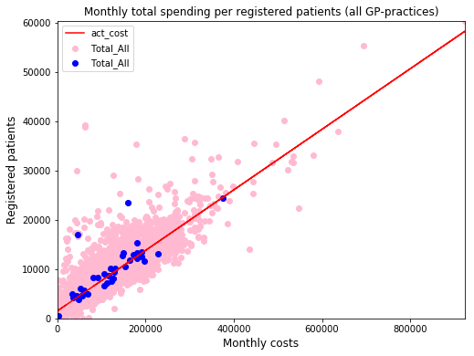

```python
#3.Visualize the monthly total spending per registered patients for all GP-practices in a scatterplot, show a trend line, and visualize the data for your city within the national scatterplot
#Create a scatterplot
from math import floor
fig=plt.figure(figsize=(8, 6))
ax=fig.add_subplot(111)
x= monthlyandtotal['act_cost']
y = monthlyandtotal['Total_All']
x1= monthlyandtotal_s['act_cost']
y1= monthlyandtotal_s['Total_All']
ax.scatter(x, y, color='#FFBAD2')
ax.scatter(x1, y1, color='blue')
fit = np.polyfit(x, y, deg=1)
ax.plot(x, fit[0] * x + fit[1], color='red')
ax.set_title("Monthly total spending per registered patients (all GP-practices)")
ax.set_xlabel("Monthly costs",fontsize=12)
ax.set_ylabel("Registered patients",fontsize=12)
max_x = floor(monthlyandtotal.act_cost.max())
max_y = floor(monthlyandtotal.Total_All.max())
ax.set_xlim(0, max_x)
ax.set_ylim(0, max_y)
ax.legend()
```

```python
#Delete outliers
sortedrelativecosts= monthlyandtotal.sort_values(by=['relativecosts'], ascending=False)
sortedrelativecosts.head()
```

|  | practice | act_cost | Total_All | relativecosts |
| --- | --- | --- | --- | --- |
| 2550 | E87723 | 58319.78 | 1 | 58319.780000 |
| 3543 | G82651 | 3358.69 | 1 | 3358.690000 |
| 7452 | Y01924 | 71547.74 | 112 | 638.819107 |
| 7607 | Y02873 | 4960.98 | 20 | 248.049000 |
| 7458 | Y02045 | 626.88 | 4 | 156.720000 |

```python
relativecostsoutliers= sortedrelativecosts[30:-2]
relativecostsoutliers.head()
```

|  | practice | act_cost | Total_All | relativecosts |
| --- | --- | --- | --- | --- |
| 1661 | C88626 | 47237.04 | 1599 | 29.541614 |
| 6405 | N81655 | 10040.82 | 347 | 28.936081 |
| 2766 | F81670 | 84544.86 | 2993 | 28.247531 |
| 2802 | F81741 | 143620.38 | 5212 | 27.555714 |
| 5272 | L83643 | 50309.15 | 1849 | 27.208843 |

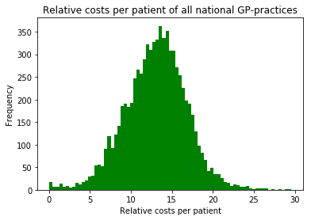

```python
#4.Visualize the relative costs per patient of all national GP-practices in a histogram.

x= relativecostsoutliers.relativecosts.values
plt.hist(x, bins=75,color='green')
plt.xlabel("Relative costs per patient")
plt.ylabel("Frequency")
plt.title("Relative costs per patient of all national GP-practices")
plt.show()
```

```python
#5.Use descriptive statistics to show how your assigned city compares to the national level.
#Descriptive statistics for all national GP practices
describenational = monthlyandtotal['relativecosts'].describe()
describenational = pd.DataFrame(describenational)
describenational
```

|  | relativecosts |
| --- | --- |
| count | 7701.000000 |
| mean | 21.317316 |
| std | 665.570655 |
| min | 0.001872 |
| 25% | 10.689451 |
| 50% | 13.212266 |
| 75% | 15.504289 |
| max | 58319.780000 |

```python
#Descriptive statistics for Southampton
describesouthampton = monthlyandtotal_s['relativecosts'].describe()
describesouthampton = pd.DataFrame(describesouthampton)
describesouthampton
```

|  | relativecosts |
| --- | --- |
| count | 39.000000 |
| mean | 12.206562 |
| std | 3.211350 |
| min | 2.729879 |
| 25% | 11.019578 |
| 50% | 12.120582 |
| 75% | 14.467226 |
| max | 17.488283 |

```python
#Create a boxplot to show how Southampton relates to the national level
desc_all= monthlyandtotal.loc[:,['relativecosts','practice']]
desc_all= desc_all.assign(Location=1)
desc_all.head()
```

|  | relativecosts | practice | Location |
| --- | --- | --- | --- |
| 0 | 19.655307 | A81001 | 1 |
| 1 | 16.937417 | A81002 | 1 |
| 2 | 14.291677 | A81003 | 1 |
| 3 | 16.117894 | A81004 | 1 |
| 4 | 13.658443 | A81005 | 1 |

```python
desc_s= monthlyandtotal_s.loc[:,['relativecosts','practice']]
desc_s= desc_s.assign(Location=2)
desc_s.head()
```

|  | relativecosts | practice | Location |
| --- | --- | --- | --- |
| 4353 | 14.651596 | J82002 | 2 |
| 4358 | 16.419526 | J82008 | 2 |
| 4369 | 14.836762 | J82022 | 2 |
| 4371 | 6.745676 | J82024 | 2 |
| 4383 | 13.869761 | J82040 | 2 |

```python
concat_desc = pd.concat([desc_all,desc_s])
concat_desc.head()
```

|  | relativecosts | practice | Location |
| --- | --- | --- | --- |
| 0 | 19.655307 | A81001 | 1 |
| 1 | 16.937417 | A81002 | 1 |
| 2 | 14.291677 | A81003 | 1 |
| 3 | 16.117894 | A81004 | 1 |
| 4 | 13.658443 | A81005 | 1 |

```python
#Delete outliers to show the boxplot
sortedconcat_desc= concat_desc.sort_values(by=['relativecosts'], ascending=False)
sortedconcat_desc.head()
```

|  | relativecosts | practice | Location |
| --- | --- | --- | --- |
| 2550 | 58319.780000 | E87723 | 1 |
| 3543 | 3358.690000 | G82651 | 1 |
| 7452 | 638.819107 | Y01924 | 1 |
| 7607 | 248.049000 | Y02873 | 1 |
| 7458 | 156.720000 | Y02045 | 1 |

```python
sortedconcat_desc_outliers= sortedconcat_desc[30:-2]
sortedconcat_desc_outliers.head()
```

|  | relativecosts | practice | Location |
| --- | --- | --- | --- |
| 1661 | 29.541614 | C88626 | 1 |
| 6405 | 28.936081 | N81655 | 1 |
| 2766 | 28.247531 | F81670 | 1 |
| 2802 | 27.555714 | F81741 | 1 |
| 5272 | 27.208843 | L83643 | 1 |

```
(0, 29)
```

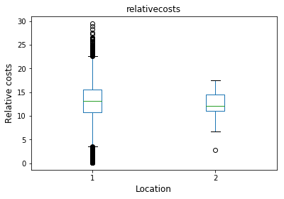

```python
bx= sortedconcat_desc_outliers.boxplot(column='relativecosts', by='Location', grid=False)
bx.set_xlabel("Location",fontsize=12)
bx.set_ylabel("Relative costs",fontsize=12)
plt.suptitle("")
max_y = floor(sortedconcat_desc_outliers.relativecosts.max())
ax.set_ylim(0, max_y)
```

# Assignment C [25 marks]

# Using the entire dataset from the HSCIC GP Practice Prescribing data, address the following queries using a combination of narrative, tables, figures and descriptive statistcs:

# Identify for all GP-practices the relative costs per patient for all statin prescriptions (simvastatin, atorvastatin, rosuvastatin, pravastatin, fluvastatin) by using the dataset from December 2015.

# Identify for all GP-practice the associated Index of Multiple Deprivation (IMD) for each GP-Practice in your assigned city.

# Use the entire national dataset and identify the lowest relative spenders of statins from the first decile and the highest relative spenders of statins from the last decile. Now determine for all identified GP-practices for both groups (lowest and the highest) the associated Index of Multiple Deprivation (IMD). Use these two groups to assess whether the IMD-score differs. Use descriptive statistics for your answer.

# Identify for all GP-practices the associated nine English regions. Identify for each region the associated 75 mortality rate for cardiovascular diseases for the year 2015.

# Visualize (using matplotlib) for each region spending for statins [x-axis] and the mortality rate [y-axis]. Assess whether relative spending for statin prescriptions in each regions correlates with the mortality rate from cardiovascular diseases.

```python
#Identify for all GP-practices the relative costs per patient for all statin prescriptions
statinsdataset= prescribingdataset.loc[prescribingdataset['bnf_name'].str.contains('statin', case=False)]
statinsdataset.head()
```

|  | sha | pct | practice | bnf_code | bnf_name | items | nic | act_cost | quantity | period |
| --- | --- | --- | --- | --- | --- | --- | --- | --- | --- | --- |
| 102 | Q44 | RXA | Y00327 | 0212000B0AAACAC | Atorvastatin_Tab 40mg | 2 | 1.67 | 1.67 | 29 | 201512 |
| 103 | Q44 | RXA | Y00327 | 0212000Y0AAABAB | Simvastatin_Tab 20mg | 1 | 0.10 | 0.20 | 3 | 201512 |
| 274 | Q44 | RXA | Y00327 | 0502030B0AAABAB | Nystatin_Oral Susp 100 000u/ml | 10 | 25.90 | 24.08 | 300 | 201512 |
| 512 | Q44 | RXA | Y04109 | 0502030B0AAABAB | Nystatin_Oral Susp 100 000u/ml | 1 | 2.59 | 2.41 | 30 | 201512 |
| 647 | Q44 | RY7 | N85638 | 0212000B0AAABAB | Atorvastatin_Tab 20mg | 1 | 0.70 | 0.76 | 14 | 201512 |

```python
statinsdataset= statinsdataset.groupby('practice')['act_cost'].sum().reset_index()
statinsdataset.head()
```

|  | practice | act_cost |
| --- | --- | --- |
| 0 | A81001 | 1816.80 |
| 1 | A81002 | 6530.36 |
| 2 | A81003 | 868.39 |
| 3 | A81004 | 2139.41 |
| 4 | A81005 | 1891.93 |

```python
statinsdataset= pd.merge(left=statinsdataset, right=totalall, on='practice')
statinsdataset.head()
```

|  | practice | act_cost | Total_All |
| --- | --- | --- | --- |
| 0 | A81001 | 1816.80 | 4234 |
| 1 | A81002 | 6530.36 | 19691 |
| 2 | A81003 | 868.39 | 3357 |
| 3 | A81004 | 2139.41 | 9151 |
| 4 | A81005 | 1891.93 | 7883 |

```python
#Obtain the relative costs for all statin prescriptions for each GP-practice
statinsdataset['relativecosts'] = statinsdataset['act_cost']/statinsdataset['Total_All']
statinsdataset.head()
```

|  | practice | act_cost | Total_All | relativecosts |
| --- | --- | --- | --- | --- |
| 0 | A81001 | 1816.80 | 4234 | 0.429098 |
| 1 | A81002 | 6530.36 | 19691 | 0.331642 |
| 2 | A81003 | 868.39 | 3357 | 0.258680 |
| 3 | A81004 | 2139.41 | 9151 | 0.233790 |
| 4 | A81005 | 1891.93 | 7883 | 0.240001 |

```python
#Relative costs of statins for each GP-practice
statins_relativecosts= statinsdataset.loc[:,['practice','relativecosts']]
statins_relativecosts.head()
```

|  | practice | relativecosts |
| --- | --- | --- |
| 0 | A81001 | 0.429098 |
| 1 | A81002 | 0.331642 |
| 2 | A81003 | 0.258680 |
| 3 | A81004 | 0.233790 |
| 4 | A81005 | 0.240001 |

```python
#Identify for all GP-practice the associated Index of Multiple Deprivation (IMD) for each GP-Practice in your assigned city.
url_4 = 'https://s3.eu-west-2.amazonaws.com/dmhr-data/deprivation-by-postcode.csv'
imd = pd.read_csv(url_4)
imd.head()
```

|  | Postcode | Postcode Status | LSOA code | LSOA Name | Index of Multiple Deprivation Rank | Index of Multiple Deprivation Decile | Income Rank | Income Decile | Income Score | Employment Rank | ... | Barriers to Housing and Services Rank | Barriers to Housing and Services Decile | Living Environment Rank | Living Environment Decile | IDACI Rank | IDACI Decile | IDACI Score | IDAOPI Rank | IDAOPI Decile | IDAOPI Score |
| --- | --- | --- | --- | --- | --- | --- | --- | --- | --- | --- | --- | --- | --- | --- | --- | --- | --- | --- | --- | --- | --- |
| 0 | TS18 1HU | Live | E01033477 | Stockton-on-Tees 014G E01033477 | 73.0 | 1.0 | 196.0 | 1.0 | 0.474 | 123.0 | ... | 20035.0 | 7.0 | 2868.0 | 1.0 | 2226.0 | 1.0 | 0.422 | 817.0 | 1.0 | 0.500 |
| 1 | TS18 2AW | Live | E01012267 | Stockton-on-Tees 014F E01012267 | 551.0 | 1.0 | 433.0 | 1.0 | 0.434 | 215.0 | ... | 25114.0 | 8.0 | 16862.0 | 6.0 | 4415.0 | 2.0 | 0.354 | 427.0 | 1.0 | 0.552 |
| 2 | TS26 8DB | Live | E01011999 | Hartlepool 007D E01011999 | 967.0 | 1.0 | 746.0 | 1.0 | 0.402 | 678.0 | ... | 27634.0 | 9.0 | 6264.0 | 2.0 | 1071.0 | 1.0 | 0.481 | 2268.0 | 1.0 | 0.409 |
| 3 | TS1 3BE | Live | E01012068 | Middlesbrough 001A E01012068 | 1914.0 | 1.0 | 3124.0 | 1.0 | 0.306 | 6166.0 | ... | 16397.0 | 5.0 | 4060.0 | 2.0 | 2212.0 | 1.0 | 0.422 | 948.0 | 1.0 | 0.488 |
| 4 | TS14 7DJ | Live | E01012117 | Redcar and Cleveland 018A E01012117 | 7082.0 | 3.0 | 5343.0 | 2.0 | 0.252 | 4058.0 | ... | 31777.0 | 10.0 | 19703.0 | 6.0 | 6666.0 | 3.0 | 0.300 | 5907.0 | 2.0 | 0.299 |

5 rows × 28 columns

```python
practice_imd_df= pd.merge(left=practicedataset, right=imd, left_on='postcode', right_on='Postcode')
practice_imd_df.head()
```

|  | period | practice | practicename | centrename | street | city | county | postcode | Postcode | Postcode Status | ... | Barriers to Housing and Services Rank | Barriers to Housing and Services Decile | Living Environment Rank | Living Environment Decile | IDACI Rank | IDACI Decile | IDACI Score | IDAOPI Rank | IDAOPI Decile | IDAOPI Score |
| --- | --- | --- | --- | --- | --- | --- | --- | --- | --- | --- | --- | --- | --- | --- | --- | --- | --- | --- | --- | --- | --- |
| 0 | 201512 | A81001 | THE DENSHAM SURGERY | THE HEALTH CENTRE | LAWSON STREET | STOCKTON ON TEES | CLEVELAND | TS18 1HU | TS18 1HU | Live | ... | 20035.0 | 7.0 | 2868.0 | 1.0 | 2226.0 | 1.0 | 0.422 | 817.0 | 1.0 | 0.5 |
| 1 | 201512 | A81001 | THE DENSHAM SURGERY | THE HEALTH CENTRE | LAWSON STREET | STOCKTON ON TEES | CLEVELAND | TS18 1HU | TS18 1HU | Live | ... | 20035.0 | 7.0 | 2868.0 | 1.0 | 2226.0 | 1.0 | 0.422 | 817.0 | 1.0 | 0.5 |
| 2 | 201512 | A81001 | THE DENSHAM SURGERY | THE HEALTH CENTRE | LAWSON STREET | STOCKTON ON TEES | CLEVELAND | TS18 1HU | TS18 1HU | Live | ... | 20035.0 | 7.0 | 2868.0 | 1.0 | 2226.0 | 1.0 | 0.422 | 817.0 | 1.0 | 0.5 |
| 3 | 201512 | A81001 | THE DENSHAM SURGERY | THE HEALTH CENTRE | LAWSON STREET | STOCKTON ON TEES | CLEVELAND | TS18 1HU | TS18 1HU | Live | ... | 20035.0 | 7.0 | 2868.0 | 1.0 | 2226.0 | 1.0 | 0.422 | 817.0 | 1.0 | 0.5 |
| 4 | 201512 | A81025 | THE DOVECOT SURGERY | THE HEALTH CENTRE | LAWSON STREET | STOCKTON ON TEES | CLEVELAND | TS18 1HU | TS18 1HU | Live | ... | 20035.0 | 7.0 | 2868.0 | 1.0 | 2226.0 | 1.0 | 0.422 | 817.0 | 1.0 | 0.5 |

5 rows × 36 columns

```python
#Select only Southampton
practice_imd_df_s= practice_imd_df[practice_imd_df['city'].str.contains('SOUTHAMPTON')]
practice_imd_df_s.head()
```

|  | period | practice | practicename | centrename | street | city | county | postcode | Postcode | Postcode Status | ... | Barriers to Housing and Services Rank | Barriers to Housing and Services Decile | Living Environment Rank | Living Environment Decile | IDACI Rank | IDACI Decile | IDACI Score | IDAOPI Rank | IDAOPI Decile | IDAOPI Score |
| --- | --- | --- | --- | --- | --- | --- | --- | --- | --- | --- | --- | --- | --- | --- | --- | --- | --- | --- | --- | --- | --- |
| 6625 | 201512 | J82002 | LORDSHILL HEALTH CENTRE | LORDSHILL HEALTH CENTRE | LORDSHILL DISTRICT CENTRE | LORDSHILL SOUTHAMPTON | HAMPSHIRE | SO16 8HY | SO16 8HY | Live | ... | 14942.0 | 5.0 | 13455.0 | 5.0 | 11285.0 | 4.0 | 0.216 | 3053.0 | 1.0 | 0.376 |
| 6630 | 201512 | J82008 | WEST END SURGERY | WEST END SURGERY | MOORGREEN ROAD WEST END | SOUTHAMPTON | HAMPSHIRE | SO30 3PY | SO30 3PY | Live | ... | 14280.0 | 5.0 | 16156.0 | 5.0 | 21264.0 | 7.0 | 0.100 | 20376.0 | 7.0 | 0.116 |
| 6650 | 201512 | J82022 | VICTOR STREET SURGERY | VICTOR STREET SURGERY | VICTOR STREET SHIRLEY | SOUTHAMPTON | HAMPSHIRE | SO15 5SY | SO15 5SY | Live | ... | 15405.0 | 5.0 | 5426.0 | 2.0 | 2509.0 | 1.0 | 0.411 | 3363.0 | 2.0 | 0.366 |
| 6652 | 201512 | J82024 | NICHOLS TOWN SURGERY | NICHOLS TOWN SURGERY | FANSHAWE WING RSH HOSP. | SOUTHAMPTON |  | SO14 0YG | SO14 0YG | Live | ... | 6371.0 | 2.0 | 214.0 | 1.0 | 15012.0 | 5.0 | 0.164 | 755.0 | 1.0 | 0.509 |
| 6653 | 201512 | J82024 | NICHOLS TOWN SURGERY | NICHOLS TOWN SURGERY | FANSHAWE WING RSH HOSP. | SOUTHAMPTON |  | SO14 0YG | SO14 0YG | Live | ... | 6371.0 | 2.0 | 214.0 | 1.0 | 15012.0 | 5.0 | 0.164 | 755.0 | 1.0 | 0.509 |

5 rows × 36 columns